# Machine Learning course project

Naomi

3/25/2018

## Project summary

Using devices such as Jawbone Up, Nike FuelBand, and Fitbit it is now possible to collect a large amount of data about personal activity relatively inexpensively.

One thing that people regularly do is quantify how much of a particular activity they do, but they rarely quantify how well they do it. In this project, the goal is to use data from accelerometers on the belt, forearm, arm, and dumbell of 6 participants. They were asked to perform barbell lifts correctly and incorrectly in 5 different ways. The goal of this project is to predict the manner in which they did the exercise.

## Data Import and Cleaning

```r
library(readr)
library(lattice)
library(ggplot2)
library (caret)
library(randomForest)
library(rpart)
library(rpart.plot)

training = read.csv("https://d396qusza40orc.cloudfront.net/predmachlearn/pml-training.csv")
testing = read.csv("https://d396qusza40orc.cloudfront.net/predmachlearn/pml-testing.csv")

set.seed(13)
inTrain  <- createDataPartition(training$classe, p=0.75, list=FALSE)
training2 <- training[inTrain, ]
testing2 <- training[-inTrain, ]
dim(training2)
```

```
## [1] 14718   160
```

```r
dim(testing2)
```

```
## [1] 4904  160
```

```r
#Remove variables with nearly zero variance
nearzero<-nearZeroVar(training2)
training2<-training2[,-nearzero]
testing2<-testing2[,-nearzero]

dim(training2)
```

```
## [1] 14718   105
```

```r
dim(testing2)
```

```
## [1] 4904  105
```

```r
#Remove variables with mostly NAs
training2 <- training2[,colSums(is.na(training2))==0]
testing2<-testing2[,colSums(is.na(testing2))==0]

dim(training2)
```

```
## [1] 14718    59
```

```r
dim(testing2)
```

```
## [1] 4904   59
```

```r
#Remove ID columns
training2<-training2[,-(1:5)]
testing2<-testing2[,-(1:5)]

dim(training2)
```

```
## [1] 14718    54
```

```r
dim(testing2)
```

```
## [1] 4904   54
```

## Prediction algorithms

This section will use classification trees, random forests, and gbm to predict the outcome.

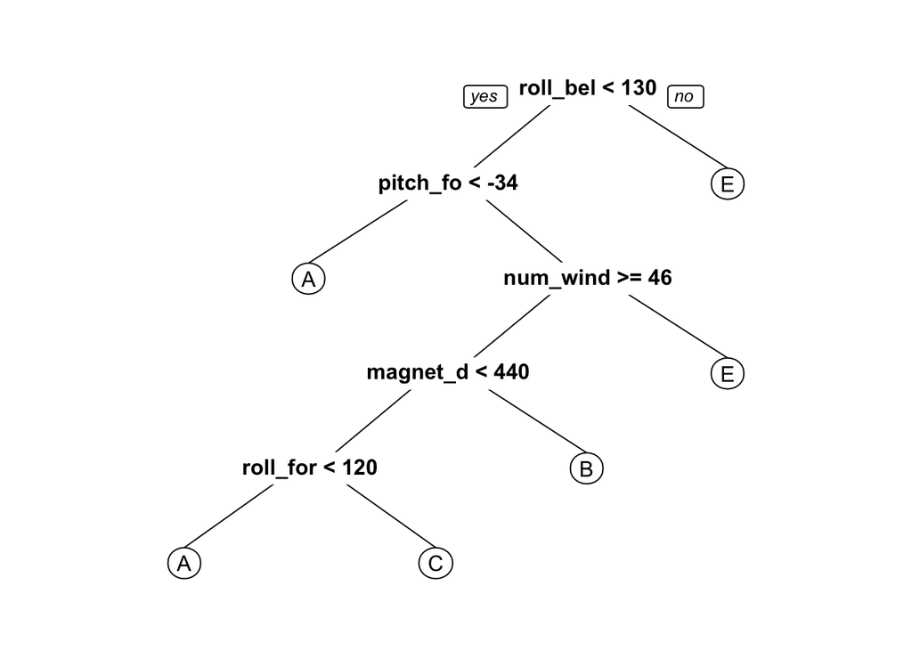

```r
#Test different prediction models and accuracy
control <- trainControl(method = "cv", number = 5)

#Decision tree using rpart
set.seed(13)
modFitRPart<-train(classe~., data=training2, method="rpart", trControl=control)
prp(modFitRPart$finalModel)
```

```r
print(modFitRPart)
```

```
## CART
##
## 14718 samples
##    53 predictor
##     5 classes: 'A', 'B', 'C', 'D', 'E'
##
## No pre-processing
## Resampling: Cross-Validated (5 fold)
## Summary of sample sizes: 11775, 11774, 11775, 11774, 11774
## Resampling results across tuning parameters:
##
##   cp          Accuracy   Kappa
##   0.03878287  0.5510949  0.42625588
##   0.05511250  0.4207784  0.21480902
##   0.11497199  0.3327832  0.07378065
##
## Accuracy was used to select the optimal model using the largest value.
## The final value used for the model was cp = 0.03878287.
```

```r
#Predict on test set
pred_rpart<-predict(modFitRPart, testing2)
confusionMatrix(pred_rpart, testing2$classe)
```

```
## Confusion Matrix and Statistics
##
##           Reference
## Prediction    A    B    C    D    E
##          A 1254  368  392  342   86
##          B   23  332   24  147   76
##          C  114  249  439  282  200
##          D    0    0    0    0    0
##          E    4    0    0   33  539
##
## Overall Statistics
##
##                Accuracy : 0.5228
##                  95% CI : (0.5087, 0.5369)
##     No Information Rate : 0.2845
##     P-Value [Acc > NIR] : < 2.2e-16
##
##                   Kappa : 0.3782
##  Mcnemar's Test P-Value : < 2.2e-16
##
## Statistics by Class:
##
##                      Class: A Class: B Class: C Class: D Class: E
## Sensitivity            0.8989   0.3498  0.51345   0.0000   0.5982
## Specificity            0.6614   0.9317  0.79131   1.0000   0.9908
## Pos Pred Value         0.5135   0.5515  0.34190      NaN   0.9358
## Neg Pred Value         0.9427   0.8566  0.88508   0.8361   0.9164
## Prevalence             0.2845   0.1935  0.17435   0.1639   0.1837
## Detection Rate         0.2557   0.0677  0.08952   0.0000   0.1099
## Detection Prevalence   0.4980   0.1228  0.26183   0.0000   0.1175
## Balanced Accuracy      0.7802   0.6408  0.65238   0.5000   0.7945
```

## Random Forest model

```r
#Random Forest
set.seed(13)
modFit_RF<-randomForest(classe~., data=training2)

#Predict on test set
pred_rf<-predict(modFit_RF, testing2)
confusionMatrix(pred_rf, testing2$classe)
```

```
## Confusion Matrix and Statistics
##
##           Reference
## Prediction    A    B    C    D    E
##          A 1395    2    0    0    0
##          B    0  947    4    0    0
##          C    0    0  851    6    0
##          D    0    0    0  798    2
##          E    0    0    0    0  899
##
## Overall Statistics
##
##                Accuracy : 0.9971
##                  95% CI : (0.9952, 0.9984)
##     No Information Rate : 0.2845
##     P-Value [Acc > NIR] : < 2.2e-16
##
##                   Kappa : 0.9964
##  Mcnemar's Test P-Value : NA
##
## Statistics by Class:
##
##                      Class: A Class: B Class: C Class: D Class: E
## Sensitivity            1.0000   0.9979   0.9953   0.9925   0.9978
## Specificity            0.9994   0.9990   0.9985   0.9995   1.0000
## Pos Pred Value         0.9986   0.9958   0.9930   0.9975   1.0000
## Neg Pred Value         1.0000   0.9995   0.9990   0.9985   0.9995
## Prevalence             0.2845   0.1935   0.1743   0.1639   0.1837
## Detection Rate         0.2845   0.1931   0.1735   0.1627   0.1833
## Detection Prevalence   0.2849   0.1939   0.1748   0.1631   0.1833
## Balanced Accuracy      0.9997   0.9984   0.9969   0.9960   0.9989
```

## Boosted model (gbm)

```r
#Boosted model (GBM)
set.seed(13)
modFitGBM<-train(classe~., method ="gbm", data=training2, trControl=control, verbose=FALSE)

#Predict on test set
pred_gbm<-predict(modFitGBM, testing2)
confMat<-confusionMatrix(pred_gbm, testing2$classe)
```

The accuracy for each method was as follows. Decision tree: 0.5228 Random forest: 0.9971 Gradient boosting: 0.9882

As random forest is the most accurate, with a 0.0029 out of sample error. We now use the random forest to predict the outcome variable (classe) on the test set.

```r
predict(modFit_RF, testing)
```

```
##  1  2  3  4  5  6  7  8  9 10 11 12 13 14 15 16 17 18 19 20
##  B  A  B  A  A  E  D  B  A  A  B  C  B  A  E  E  A  B  B  B
## Levels: A B C D E
```